# Visualizations of Dataset

Different visualizations

Doris Liu

2018-12-07

## About my Dataset

This is a table from Rstudio, which is called **Titanic**. It is converted into data frame in this blog post. This dataset will be the sample that we are using to display different visualizations avaliable in R.

Below are some basic information about the data set:

- **column names:** Class, Sex, Age, Survived, Freq
- **head:**

```
##   Class    Sex   Age Survived Freq
## 1   1st   Male Child       No    0
## 2   2nd   Male Child       No    0
## 3   3rd   Male Child       No   35
## 4  Crew   Male Child       No    0
## 5   1st Female Child       No    0
## 6   2nd Female Child       No    0
```

- **number of rows:** 32

## Table

The most direct way to display data is to display the dataset as a table.

- Package: *knitr*

we are able to display dataset as a table format, like this:

```r
kable(my_data_head, caption = "Survival Rate for Titanic")
```

Survival Rate for Titanic

| Class | Sex | Age | Survived | Freq |
| --- | --- | --- | --- | --- |
| 1st | Male | Child | No | 0 |
| 2nd | Male | Child | No | 0 |
| 3rd | Male | Child | No | 35 |
| Crew | Male | Child | No | 0 |
| 1st | Female | Child | No | 0 |
| 2nd | Female | Child | No | 0 |

- Add caption for table by using: *caption = “caption_for_table”*.

## Line Chart

Line chart is a good way to see the trend of a series of data.

- Package: *ggplot2*

Plot a line chart, like this:

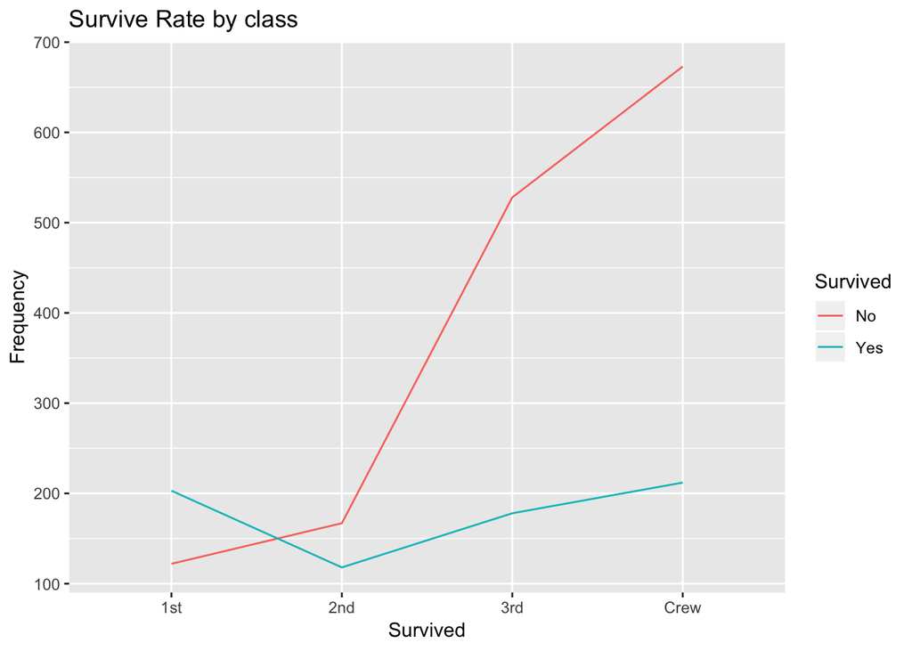

```r
class_survive <- my_dataframe %>%
  group_by(Survived, Class) %>%
  summarise("sum" = sum(Freq))

ggplot(class_survive, aes(Class, sum, group= class_survive$Survived)) +
  ggtitle("Survive Rate by class") +
  xlab("Survived") + ylab("Frequency") +
  geom_line(aes(col = Survived))
```

* Add color for lines by using: *aes(col = name_of_variable)*

## Bar Chart

Bar chart is great for showing frequencies of data and compare the numbers.

- Package: *ggplot2*

Plot a bar chart, like this:

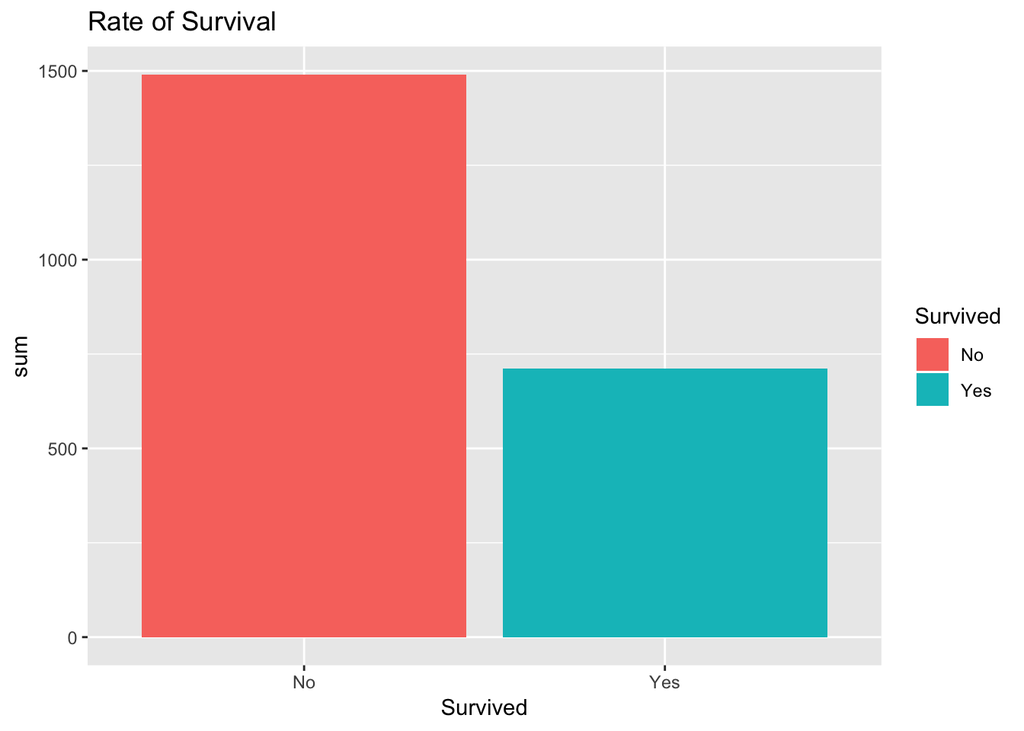

```r
group_data <- my_dataframe %>%
  group_by(Survived) %>%
  summarise("sum" = sum(Freq))

ggplot(group_data) +
      geom_bar(mapping = aes(x = Survived, y = sum, fill = Survived), stat = "identity") +
      labs(title = "Rate of Survival")
```

- Add a title for chart by using: *title = “title_for_chart”*
- Fill colors for the bars by using: *are(fill = variable_name)*